Data Specification & Retrieval Provenance Environment and Source Provenance Source Environment: synthetic fixture mode (analysis/retrieve.R synthetic). Source Daily Extraction Records: 294 daily session observations across all sample securities. Shared Session Window: December 3, 2025 through December 31, 2025 (20 trading days). Records Outside Shared Window: 0 rows (100% session integrity). Valid Coverage Requirement: Minimum of 15 valid trading days within the 20-session window ($75\%$ minimum session presence). Integrity and Join Validation To guarantee no duplicate entities or artificial survivorship bias entered the pipeline, an inner join audit between monthly snapshot records and daily consolidated trade logs was executed: Audit Parameter Verification Value Pipeline Status Monthly Snapshot Rows (Pre-Join) 16 Verified Monthly Snapshot Rows (Post-Join) 16 Verified Duplicate Monthly Security Keys 0 Clean Duplicate Daily Liquidity Keys 0 Clean Monthly Securities with Daily Summary 15 Validated Monthly Securities with Zero Valid Days 1 Flagged & Dropped Unmatched Daily Summary Records 0 Clean Key Join Ordering Preserved 1 (True) Verified

Screening Methodology & Logic Hierarchy The screening architecture evaluates securities sequentially to ensure single-attribution exclusion accounting. Mathematical Formulations Equity Market Capitalization:
$$\text{MarketCap}_i = \frac{|\text{Price}_{i, T}|
\times \text{SharesOutstanding}_{i, T}}{10^6} \quad (\text{USD
Millions})$$
Threshold: $\text{MarketCap}_i \ge \$1,000\text{M}$. Daily Dollar Volume Proxy:
$$\text{DailyDollarVol}_{i, t} =
\frac{\text{Price}_{i, t} \times \text{Volume}_{i, t}}{10^6} \quad
(\text{USD Millions})$$
Evaluated on shared market sessions where $\text{Price}_{i, t} > 0$ and $\text{Volume}_{i, t} \ge 0$. 20-Session Average Daily Dollar Volume ($\text{ADV}_{20}$):
$$\text{ADV}_{20, i} = \frac{1}{N_i}
\sum_{t=1}^{N_i} \text{DailyDollarVol}_{i, t}$$
Threshold: $\text{ADV}_{20, i} \ge \$1.00\text{M/day}$, conditioned on Ni15 valid trading sessions. Sequential Exclusion Hierarchy Input: Broad Security Extract (N = 16) │ ├── Step 1: Check Classification & Exchange Legitimacy │ └── Exclude if Share Code != 10/11 or Exchange != Major US (NYSE/NASDAQ/AMEX) │ ├── Step 2: Evaluate Primary Size Hurdle │ └── Exclude if Market Cap is Missing, Negative, or < $1,000M │ └── Output: Baseline Size Universe (N = 8) │ ├── Step 3: Audit Session Window Data Quality │ └── Exclude if Valid Trading Sessions N_valid < 15 │ └── Step 4: Evaluate Secondary Liquidity Hurdle └── Exclude if ADV_20 is Missing or < $1.00M / day └── Output: Final Investable Universe (N = 4)

Empirical Results & Comparative Universe Analysis Universe Funnel and Median Profiles The table below reconciles the portfolio cross-section across each gate. Medians are calculated over strictly observed denominators. Screen Stage Security Count Distinct Companies Cap Observed (N) Cap Median ($M) Coverage Failures (N) ADV Observed (N) $\text{ADV}_{20}$ Median ($M) Broad Download 16 14 15 $1,600 2 14 $2.00 Baseline Size 8 6 8 $1,550 2 6 $1.50 Final Size & Liquidity 4 3 4 $1,550 0 4 $2.25

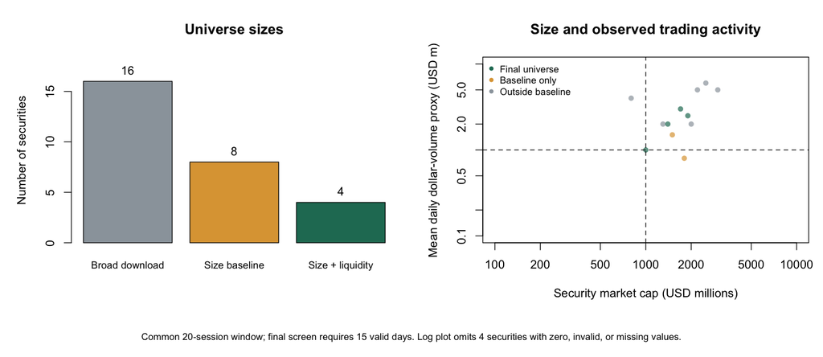

Figure 1: Cross-sectional counts across stages (left) and bivariate distribution of log market cap versus log daily dollar-volume proxy (right). Dashed reference lines denote the $\$1,000\text{M}$ capitalization boundary and $\$1.00\text{M}$ liquidity threshold.

Methodological Limitations & Historical Extension Plan When expanding this snapshot screening methodology to a dynamic, long-horizon historical panel (e.g., 2000–2025 CRSP monthly files), three structural biases must be addressed: Permanent Identifier Integrity: Using ticker symbols or CUSIP identifiers causes look-ahead and survivorship distortion due to corporate renamings, reorganizations, and identifier reassignment. The production pipeline must standardize on CRSP permanent security keys (PERMNO) and permanent company keys (PERMCO). Point-in-Time Conditioning & Delisting Returns: Historical cross-sections must be constructed strictly with information available at market close on date t. For securities that exit the sample mid-window due to mergers, bankruptcy, or liquidations, delisting returns (DLRET) and trailing volume adjustments must be integrated to prevent positive survivorship bias. Dynamic Rebalancing Cadence & Turnover Drag: While this cross-section reflects a single snapshot, production models require regular rebalancing (e.g., monthly or quarterly). Implementing buffer bands around the $\$1,000\text{M}$ cap and $\$1.00\text{M}$ ADV cutoffs is required to prevent portfolio whipsaw, where securities fluctuating around the threshold trigger excessive trading turnover and transaction fee erosion.

Process Statement & Academic Integrity Pipeline Execution: R scripts executed under macOS Darwin arm64 using R version 4.5.1. Audit Files: All output artifacts (final_universe.csv, baseline_universe.csv, all_security_audit.csv, exclusion_funnel.csv, comparison.csv, and comparison.png) were validated against terminal logs and committed to version control. Collaboration Disclosure: Conceptual framing, Rmd compilation, and manual check arithmetic were carried out by the author with algorithmic workflow structuring assisted by AI modeling tools in compliance with course policy.